# Exploration of Ford GoBike Trip Data

## Preliminary Wrangling

> Ford GoBike Trip data describes members gender, birth year, memberships' type does he subscribed or a customer, start stations names, end stations names with theirs' latitudes and longitudes, and trip durations in seconds.

```python
# import all packages and set plots to be embedded inline
import numpy as np
import pandas as pd
import matplotlib.pyplot as plt
import seaborn as sb

%matplotlib inline
```

```python
# read the csv file
df = pd.read_csv('201902-fordgobike-tripdata.csv')

#assess table's rows and columns
df.shape
```

```
(183412, 16)
```

```python
#assess columns's datatypes
df.dtypes
```

```
duration_sec                 int64
start_time                  object
end_time                    object
start_station_id           float64
start_station_name          object
start_station_latitude     float64
start_station_longitude    float64
end_station_id             float64
end_station_name            object
end_station_latitude       float64
end_station_longitude      float64
bike_id                      int64
user_type                   object
member_birth_year          float64
member_gender               object
bike_share_for_all_trip     object
dtype: object
```

```python
#assess the table visually
df.head()
```

|  | duration_sec | start_time | end_time | start_station_id | start_station_name | start_station_latitude | start_station_longitude | end_station_id | end_station_name | end_station_latitude | end_station_longitude | bike_id | user_type | member_birth_year | member_gender | bike_share_for_all_trip |
| --- | --- | --- | --- | --- | --- | --- | --- | --- | --- | --- | --- | --- | --- | --- | --- | --- |
| 0 | 52185 | 2019-02-28 17:32:10.1450 | 2019-03-01 08:01:55.9750 | 21.0 | Montgomery St BART Station (Market St at 2nd St) | 37.789625 | -122.400811 | 13.0 | Commercial St at Montgomery St | 37.794231 | -122.402923 | 4902 | Customer | 1984.0 | Male | No |
| 1 | 42521 | 2019-02-28 18:53:21.7890 | 2019-03-01 06:42:03.0560 | 23.0 | The Embarcadero at Steuart St | 37.791464 | -122.391034 | 81.0 | Berry St at 4th St | 37.775880 | -122.393170 | 2535 | Customer | NaN | NaN | No |
| 2 | 61854 | 2019-02-28 12:13:13.2180 | 2019-03-01 05:24:08.1460 | 86.0 | Market St at Dolores St | 37.769305 | -122.426826 | 3.0 | Powell St BART Station (Market St at 4th St) | 37.786375 | -122.404904 | 5905 | Customer | 1972.0 | Male | No |
| 3 | 36490 | 2019-02-28 17:54:26.0100 | 2019-03-01 04:02:36.8420 | 375.0 | Grove St at Masonic Ave | 37.774836 | -122.446546 | 70.0 | Central Ave at Fell St | 37.773311 | -122.444293 | 6638 | Subscriber | 1989.0 | Other | No |
| 4 | 1585 | 2019-02-28 23:54:18.5490 | 2019-03-01 00:20:44.0740 | 7.0 | Frank H Ogawa Plaza | 37.804562 | -122.271738 | 222.0 | 10th Ave at E 15th St | 37.792714 | -122.248780 | 4898 | Subscriber | 1974.0 | Male | Yes |

```python
# check null values in all columns
df.isna().sum()
```

```
duration_sec                  0
start_time                    0
end_time                      0
start_station_id            197
start_station_name          197
start_station_latitude        0
start_station_longitude       0
end_station_id              197
end_station_name            197
end_station_latitude          0
end_station_longitude         0
bike_id                       0
user_type                     0
member_birth_year          8265
member_gender              8265
bike_share_for_all_trip       0
dtype: int64
```

```python
# make a copy of the dataframe
df_clean_copy = df.copy()
df_clean_copy
```

|  | duration_sec | start_time | end_time | start_station_id | start_station_name | start_station_latitude | start_station_longitude | end_station_id | end_station_name | end_station_latitude | end_station_longitude | bike_id | user_type | member_birth_year | member_gender | bike_share_for_all_trip |
| --- | --- | --- | --- | --- | --- | --- | --- | --- | --- | --- | --- | --- | --- | --- | --- | --- |
| 0 | 52185 | 2019-02-28 17:32:10.1450 | 2019-03-01 08:01:55.9750 | 21.0 | Montgomery St BART Station (Market St at 2nd St) | 37.789625 | -122.400811 | 13.0 | Commercial St at Montgomery St | 37.794231 | -122.402923 | 4902 | Customer | 1984.0 | Male | No |
| 1 | 42521 | 2019-02-28 18:53:21.7890 | 2019-03-01 06:42:03.0560 | 23.0 | The Embarcadero at Steuart St | 37.791464 | -122.391034 | 81.0 | Berry St at 4th St | 37.775880 | -122.393170 | 2535 | Customer | NaN | NaN | No |
| 2 | 61854 | 2019-02-28 12:13:13.2180 | 2019-03-01 05:24:08.1460 | 86.0 | Market St at Dolores St | 37.769305 | -122.426826 | 3.0 | Powell St BART Station (Market St at 4th St) | 37.786375 | -122.404904 | 5905 | Customer | 1972.0 | Male | No |
| 3 | 36490 | 2019-02-28 17:54:26.0100 | 2019-03-01 04:02:36.8420 | 375.0 | Grove St at Masonic Ave | 37.774836 | -122.446546 | 70.0 | Central Ave at Fell St | 37.773311 | -122.444293 | 6638 | Subscriber | 1989.0 | Other | No |
| 4 | 1585 | 2019-02-28 23:54:18.5490 | 2019-03-01 00:20:44.0740 | 7.0 | Frank H Ogawa Plaza | 37.804562 | -122.271738 | 222.0 | 10th Ave at E 15th St | 37.792714 | -122.248780 | 4898 | Subscriber | 1974.0 | Male | Yes |
| ... | ... | ... | ... | ... | ... | ... | ... | ... | ... | ... | ... | ... | ... | ... | ... | ... |
| 183407 | 480 | 2019-02-01 00:04:49.7240 | 2019-02-01 00:12:50.0340 | 27.0 | Beale St at Harrison St | 37.788059 | -122.391865 | 324.0 | Union Square (Powell St at Post St) | 37.788300 | -122.408531 | 4832 | Subscriber | 1996.0 | Male | No |
| 183408 | 313 | 2019-02-01 00:05:34.7440 | 2019-02-01 00:10:48.5020 | 21.0 | Montgomery St BART Station (Market St at 2nd St) | 37.789625 | -122.400811 | 66.0 | 3rd St at Townsend St | 37.778742 | -122.392741 | 4960 | Subscriber | 1984.0 | Male | No |
| 183409 | 141 | 2019-02-01 00:06:05.5490 | 2019-02-01 00:08:27.2200 | 278.0 | The Alameda at Bush St | 37.331932 | -121.904888 | 277.0 | Morrison Ave at Julian St | 37.333658 | -121.908586 | 3824 | Subscriber | 1990.0 | Male | Yes |
| 183410 | 139 | 2019-02-01 00:05:34.3600 | 2019-02-01 00:07:54.2870 | 220.0 | San Pablo Ave at MLK Jr Way | 37.811351 | -122.273422 | 216.0 | San Pablo Ave at 27th St | 37.817827 | -122.275698 | 5095 | Subscriber | 1988.0 | Male | No |
| 183411 | 271 | 2019-02-01 00:00:20.6360 | 2019-02-01 00:04:52.0580 | 24.0 | Spear St at Folsom St | 37.789677 | -122.390428 | 37.0 | 2nd St at Folsom St | 37.785000 | -122.395936 | 1057 | Subscriber | 1989.0 | Male | No |

183412 rows × 16 columns

```python
# drop all records having null values in 'member_birth_year', and 'member_gender' columns
df_clean = df_clean_copy.dropna(axis=0,how='any',subset=['member_birth_year','member_gender'])
```

```python
# test
df_clean.isna().sum()
```

```
duration_sec                 0
start_time                   0
end_time                     0
start_station_id           195
start_station_name         195
start_station_latitude       0
start_station_longitude      0
end_station_id             195
end_station_name           195
end_station_latitude         0
end_station_longitude        0
bike_id                      0
user_type                    0
member_birth_year            0
member_gender                0
bike_share_for_all_trip      0
dtype: int64
```

```python
# convert 'member_gender','user_type','duration_sec','member_birth_year','start_time', and 'end_time' columns' datatypes
convert_columns_dtype = {'member_gender': 'category',
                         'user_type' : 'category',
                         'duration_sec': float,
                         'member_birth_year': np.int64}
df_clean['end_time'] = pd.to_datetime(df_clean['end_time'])
df_clean['start_time'] = pd.to_datetime(df_clean['start_time'])
df_clean = df_clean.astype(convert_columns_dtype)
```

```python
# test
df_clean.dtypes
```

```
duration_sec                      float64
start_time                 datetime64[ns]
end_time                   datetime64[ns]
start_station_id                  float64
start_station_name                 object
start_station_latitude            float64
start_station_longitude           float64
end_station_id                    float64
end_station_name                   object
end_station_latitude              float64
end_station_longitude             float64
bike_id                             int64
user_type                        category
member_birth_year                   int64
member_gender                    category
bike_share_for_all_trip            object
dtype: object
```

```python
# create duration_min column of duration_sec column
df_clean['duration_min'] = df_clean['duration_sec'] / 60

# test
df_clean.columns
```

```
Index(['duration_sec', 'start_time', 'end_time', 'start_station_id',
       'start_station_name', 'start_station_latitude',
       'start_station_longitude', 'end_station_id', 'end_station_name',
       'end_station_latitude', 'end_station_longitude', 'bike_id', 'user_type',
       'member_birth_year', 'member_gender', 'bike_share_for_all_trip',
       'duration_min'],
      dtype='object')
```

```python
# drop duration_sec column
df_clean.drop(['duration_sec'],axis = 1,inplace = True)
```

```python
# round values in duration_min column
df_clean['duration_min'].round(decimals=2)
```

```
0          869.75
2         1030.90
3          608.17
4           26.42
5           29.88
           ...
183407       8.00
183408       5.22
183409       2.35
183410       2.32
183411       4.52
Name: duration_min, Length: 175147, dtype: float64
```

```python
# check the final version of the dataframe
df_clean.info()
```

```
<class 'pandas.core.frame.DataFrame'>
Int64Index: 175147 entries, 0 to 183411
Data columns (total 16 columns):
 #   Column                   Non-Null Count   Dtype
---  ------                   --------------   -----
 0   start_time               175147 non-null  datetime64[ns]
 1   end_time                 175147 non-null  datetime64[ns]
 2   start_station_id         174952 non-null  float64
 3   start_station_name       174952 non-null  object
 4   start_station_latitude   175147 non-null  float64
 5   start_station_longitude  175147 non-null  float64
 6   end_station_id           174952 non-null  float64
 7   end_station_name         174952 non-null  object
 8   end_station_latitude     175147 non-null  float64
 9   end_station_longitude    175147 non-null  float64
 10  bike_id                  175147 non-null  int64
 11  user_type                175147 non-null  category
 12  member_birth_year        175147 non-null  int64
 13  member_gender            175147 non-null  category
 14  bike_share_for_all_trip  175147 non-null  object
 15  duration_min             175147 non-null  float64
dtypes: category(2), datetime64[ns](2), float64(7), int64(2), object(3)
memory usage: 20.4+ MB
```

```python
print(df_clean.describe())
```

```
       start_station_id  start_station_latitude  start_station_longitude  \
count     174952.000000           175147.000000            175147.000000
mean         139.002126               37.770814              -122.351305
std          111.648819                0.101070                 0.118453
min            3.000000               37.317298              -122.453704
25%           47.000000               37.770407              -122.411901
50%          104.000000               37.780760              -122.398279
75%          239.000000               37.797320              -122.283093
max          398.000000               37.880222              -121.874119

       end_station_id  end_station_latitude  end_station_longitude  \
count   174952.000000         175147.000000          175147.000000
mean       136.604486             37.771007            -122.350881
std        111.335635              0.100978               0.118018
min          3.000000             37.317298            -122.453704
25%         44.000000             37.770407            -122.411647
50%        101.000000             37.781010            -122.397405
75%        238.000000             37.797673            -122.285171
max        398.000000             37.880222            -121.874119

             bike_id  member_birth_year   duration_min
count  175147.000000      175147.000000  175147.000000
mean     4482.252639        1984.806437      11.736864
std      1658.303747          10.116689      27.360139
min        11.000000        1878.000000       1.016667
25%      3802.000000        1980.000000       5.383333
50%      4959.000000        1987.000000       8.500000
75%      5505.000000        1992.000000      13.150000
max      6645.000000        2001.000000    1409.133333
```

### What is the structure of your dataset?

> The structure of Ford GoBike Trip dataset is 183412 records, and 16 columns. Columns datatypes between string, int, and float datatype.

### What is/are the main feature(s) of interest in your dataset?

> Which gender spend more trip duration? and which age stage? my main features of interest are:
> - Trip duration
> - Member age
> - User type
> - Member gender

### What features in the dataset do you think will help support your investigation into your feature(s) of interest?

> I expect the age of the member and the gender of the member to play a major role in influencing the duration of the trip.

## Univariate Exploration

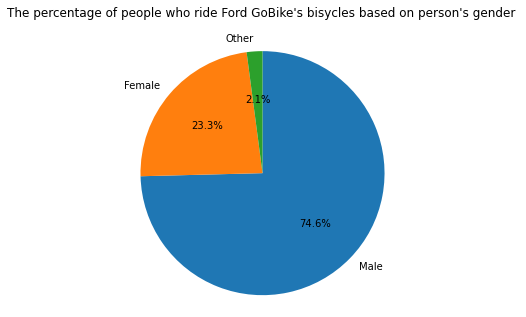

```python
# sort values based on member_gender
sorted_counts = df_clean['member_gender'].value_counts()

# figure size
plt.figure(figsize = [7, 5])

# set pie chart
plt.pie(sorted_counts, labels = sorted_counts.index, startangle = 90, counterclock = False,autopct='%1.1f%%');

plt.title("The percentage of people who ride Ford GoBike's bisycles based on person's gender \n")
plt.axis('square');
```

#### As we can see here, about three-quarters of Ford GoBike's riders are males by 74.6%, females are 23%, and other genders are 2.1%.

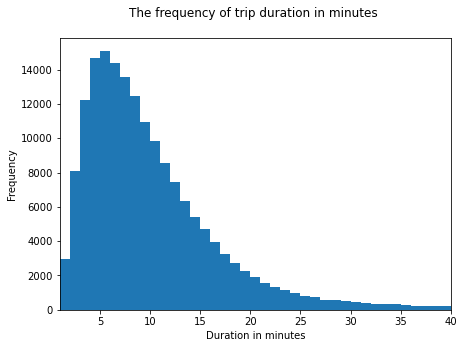

```python
# figure size
plt.figure(figsize = [7, 5])

# set histogram chart
bins=np.arange(0,df_clean['duration_min'].max()+1,1)
plt.hist(data=df_clean,x='duration_min',bins=bins);
plt.xlim(1,40)
plt.title('The frequency of trip duration in minutes \n')
plt.xlabel('Duration in minutes')
plt.ylabel('Frequency');
```

#### It is clear from the distribution of the frequency of trip duration in minutes that it's a right-skewed with a long tail on the right side. The more minutes, the frequency gets lower as expected, and the most frequent trip duration is between 4-6 minutes

```python
df_clean.duration_min.value_counts()
```

```
4.533333      308
5.383333      285
5.083333      282
6.150000      280
4.566667      276
             ...
67.483333       1
152.900000      1
77.733333       1
85.983333       1
103.050000      1
Name: duration_min, Length: 4432, dtype: int64
```

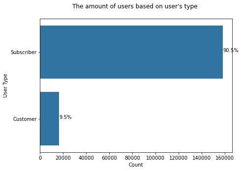

```python
# figure size
plt.figure(figsize = [7, 5])

# set Bar chart
bars_color = sb.color_palette()[0]
bars_order = df_clean['user_type'].value_counts().index
type_counts = df_clean['user_type'].value_counts()
n_users = df_clean['user_type'].value_counts().sum()
ax = sb.countplot(data=df_clean,y='user_type',color=bars_color,order=bars_order);

# set percentages
for p in ax.patches:
        percentage = '{:.1f}%'.format(100 * p.get_width()/n_users)
        x = p.get_x() + p.get_width()
        y = p.get_y() + p.get_height()/2
        ax.annotate(percentage, (x, y))
plt.title("The amount of users based on user's type \n")
plt.xlabel('Count')
plt.ylabel('User Type');
```

#### As we can see here, its so obvious that most of Ford GoBike's riders are subscribers by 90.5%, and regular customers are just 9.5%.

```python
# create member_age column of member_birth_year column
df_clean['member_age'] = 2021 - df_clean['member_birth_year']

# test
df_clean.head()
```

|  | start_time | end_time | start_station_id | start_station_name | start_station_latitude | start_station_longitude | end_station_id | end_station_name | end_station_latitude | end_station_longitude | bike_id | user_type | member_birth_year | member_gender | bike_share_for_all_trip | duration_min | member_age |
| --- | --- | --- | --- | --- | --- | --- | --- | --- | --- | --- | --- | --- | --- | --- | --- | --- | --- |
| 0 | 2019-02-28 17:32:10.145 | 2019-03-01 08:01:55.975 | 21.0 | Montgomery St BART Station (Market St at 2nd St) | 37.789625 | -122.400811 | 13.0 | Commercial St at Montgomery St | 37.794231 | -122.402923 | 4902 | Customer | 1984 | Male | No | 869.750000 | 37 |
| 2 | 2019-02-28 12:13:13.218 | 2019-03-01 05:24:08.146 | 86.0 | Market St at Dolores St | 37.769305 | -122.426826 | 3.0 | Powell St BART Station (Market St at 4th St) | 37.786375 | -122.404904 | 5905 | Customer | 1972 | Male | No | 1030.900000 | 49 |
| 3 | 2019-02-28 17:54:26.010 | 2019-03-01 04:02:36.842 | 375.0 | Grove St at Masonic Ave | 37.774836 | -122.446546 | 70.0 | Central Ave at Fell St | 37.773311 | -122.444293 | 6638 | Subscriber | 1989 | Other | No | 608.166667 | 32 |
| 4 | 2019-02-28 23:54:18.549 | 2019-03-01 00:20:44.074 | 7.0 | Frank H Ogawa Plaza | 37.804562 | -122.271738 | 222.0 | 10th Ave at E 15th St | 37.792714 | -122.248780 | 4898 | Subscriber | 1974 | Male | Yes | 26.416667 | 47 |
| 5 | 2019-02-28 23:49:58.632 | 2019-03-01 00:19:51.760 | 93.0 | 4th St at Mission Bay Blvd S | 37.770407 | -122.391198 | 323.0 | Broadway at Kearny | 37.798014 | -122.405950 | 5200 | Subscriber | 1959 | Male | No | 29.883333 | 62 |

```python
# drop member_birth_year
df_clean.drop(['member_birth_year'],axis = 1,inplace = True)
df_clean.columns
```

```
Index(['start_time', 'end_time', 'start_station_id', 'start_station_name',
       'start_station_latitude', 'start_station_longitude', 'end_station_id',
       'end_station_name', 'end_station_latitude', 'end_station_longitude',
       'bike_id', 'user_type', 'member_gender', 'bike_share_for_all_trip',
       'duration_min', 'member_age'],
      dtype='object')
```

```python
# test
df_clean.head()
```

|  | start_time | end_time | start_station_id | start_station_name | start_station_latitude | start_station_longitude | end_station_id | end_station_name | end_station_latitude | end_station_longitude | bike_id | user_type | member_gender | bike_share_for_all_trip | duration_min | member_age |
| --- | --- | --- | --- | --- | --- | --- | --- | --- | --- | --- | --- | --- | --- | --- | --- | --- |
| 0 | 2019-02-28 17:32:10.145 | 2019-03-01 08:01:55.975 | 21.0 | Montgomery St BART Station (Market St at 2nd St) | 37.789625 | -122.400811 | 13.0 | Commercial St at Montgomery St | 37.794231 | -122.402923 | 4902 | Customer | Male | No | 869.750000 | 37 |
| 2 | 2019-02-28 12:13:13.218 | 2019-03-01 05:24:08.146 | 86.0 | Market St at Dolores St | 37.769305 | -122.426826 | 3.0 | Powell St BART Station (Market St at 4th St) | 37.786375 | -122.404904 | 5905 | Customer | Male | No | 1030.900000 | 49 |
| 3 | 2019-02-28 17:54:26.010 | 2019-03-01 04:02:36.842 | 375.0 | Grove St at Masonic Ave | 37.774836 | -122.446546 | 70.0 | Central Ave at Fell St | 37.773311 | -122.444293 | 6638 | Subscriber | Other | No | 608.166667 | 32 |
| 4 | 2019-02-28 23:54:18.549 | 2019-03-01 00:20:44.074 | 7.0 | Frank H Ogawa Plaza | 37.804562 | -122.271738 | 222.0 | 10th Ave at E 15th St | 37.792714 | -122.248780 | 4898 | Subscriber | Male | Yes | 26.416667 | 47 |
| 5 | 2019-02-28 23:49:58.632 | 2019-03-01 00:19:51.760 | 93.0 | 4th St at Mission Bay Blvd S | 37.770407 | -122.391198 | 323.0 | Broadway at Kearny | 37.798014 | -122.405950 | 5200 | Subscriber | Male | No | 29.883333 | 62 |

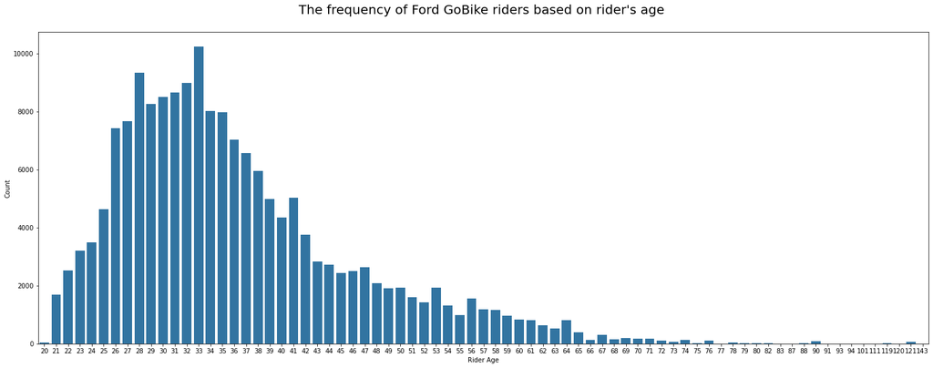

```python
# figure size
plt.figure(figsize = [25, 9])

# set Bar chart
bars_color = sb.color_palette()[0]
bars_order = df_clean['member_age'].value_counts().index
sb.countplot(data=df_clean,x='member_age',color=bars_color);
plt.title("The frequency of Ford GoBike riders based on rider's age \n",fontsize=20)
plt.xlabel('Rider Age')
plt.ylabel('Count');
```

```python
df_clean.member_age.value_counts()
```

```
33     10236
28      9325
32      8972
31      8658
30      8498
       ...
94         1
93         1
111        1
91         1
143        1
Name: member_age, Length: 75, dtype: int64
```

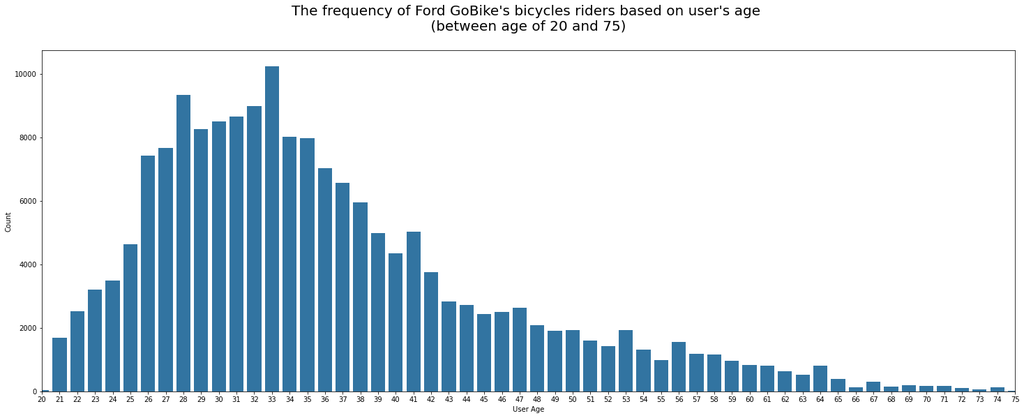

```python
# figure size
plt.figure(figsize = [25, 9])

# set Bar chart
bars_color = sb.color_palette()[0]
bars_order = df_clean['member_age'].value_counts().index
sb.countplot(data=df_clean,x='member_age',color=bars_color);
plt.title("The frequency of Ford GoBike's bicycles riders based on user's age \n (between age of 20 and 75) \n ",fontsize=20)
plt.xlabel('User Age')
plt.ylabel('Count')
plt.xlim(0,55);
```

#### The frequency of people who ride Ford GoBike's bicycles based on theirs' age, most of them are between the age of 26 and 35, and the most frequent age is 33.

```python
# create age_stage column of member_age column
df_clean['age_stage']=df_clean['member_age'].apply(lambda x: '20s' if 20<x<=29 else
                                                    '30s' if 30<x<=39 else
                                                    '40s' if 40<x<=49 else
                                                    '50s' if 50<x<=59 else
                                                    '60s' if 60<x<=69 else
                                                    '70s' if 70<x<=79 else
                                                    np.nan)
```

```python
# set the column as categories (20s,30s,40s,50s,60s,70s) and ordered
df_clean.age_stage = pd.Categorical(df_clean.age_stage,
                      categories=["20s","30s","40s","50s","60s","70s"],
                      ordered=True)
```

### Discuss the distribution(s) of your variable(s) of interest. Were there any unusual points? Did you need to perform any transformations?

> I have found some null values in member_birth_year, and member_gender columns, so i deleted all records with null values

> Most frequent age of users is 33 years old

> Most of the users are subscribers. Subscribers more than customers by 81%.

> Most frequent trip duration that people spend are between 4-6 minutes.

> Approximately three-quarters of the number of the people are males.

### Of the features you investigated, were there any unusual distributions? Did you perform any operations on the data to tidy, adjust, or change the form of the data? If so, why did you do this?

> I have done some changes to 'duration_sec', and 'member_birth_year' columns

> First: I created a column called 'duration_min' from 'duration_sec', and 'member_age' from 'member_birth_year'
> - the duration in minutes and member age numaric for making both of them to be more readable and easy to absorb.

## Bivariate Exploration

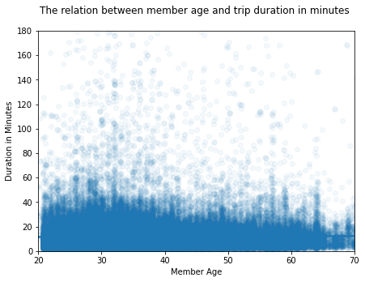

```python
# figure size
plt.figure(figsize = [7, 5])
# set Regression chart
sb.regplot(data=df_clean,x='member_age',y='duration_min',x_jitter=0.3,scatter_kws={'alpha':1/20});
plt.title('The relation between member age and trip duration in minutes \n')
plt.xlim(20,70)
plt.ylim(0,180)
plt.xlabel('Member Age')
plt.ylabel('Duration in Minutes');
```

#### As we can see here, the riders between the age of 20 and 70 years old that from less than 1 minute up to 30 minutes approximately is a common thing, and above 30 minutes are less frequent through all ages between 20 and 70 years old. There is no relationship.

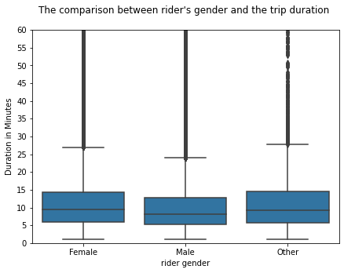

```python
# figure size
plt.figure(figsize = [7, 5])

# set Box chart
base_color = sb.color_palette()[0]
ax=sb.boxplot(data=df_clean, x='member_gender', y='duration_min', color=base_color);
plt.title("The comparison between rider's gender and the trip duration \n")
plt.xlabel('rider gender')
plt.ylabel('Duration in Minutes')
plt.ylim(0,60)
ax.set_yticks([0,5,10,15,20,25,30,35,40,45,50,55,60]);
```

#### As we can see here, that Females are spending more trip duration than Males by a few different and excluding other genders, the median of Females trip duration is 10 minutes and colse to 30 minutes as a maximum, and for Males the median is about 9 minutes, and the maximum reaches 24 minutes, without taking outliers in consideration.

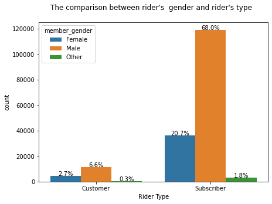

```python
# figure size
plt.figure(figsize = [7, 5])

# set Bar chart
n_users = df_clean['user_type'].value_counts().sum()
ax=sb.countplot(data=df_clean,hue='member_gender',x='user_type');
plt.title("The comparison between rider's  gender and rider's type  \n")
plt.xlabel('Rider Type')

# set percentages
for p in ax.patches:
        percentage = '{:.1f}%'.format(100 * p.get_height()/n_users)
        x = p.get_x() + p.get_width()/2
        y = p.get_y() + p.get_height()*1
        ax.annotate(percentage, (x, y),ha='center')
```

#### As we can see here from the comparison, is that most of males are subscribers by 68% ot of all, and 6.6% are customers. And same case to females, most of females are subscribers by 20.7% out of all, and 2.7% are customers.

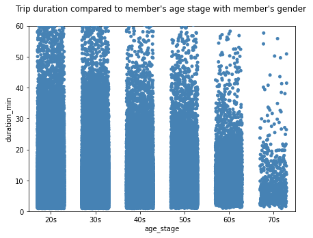

```python
# figure size
plt.figure(figsize = [7, 5])

# set striplot
ax = sb.stripplot(data = df_clean, x = 'age_stage', y = 'duration_min',
                   jitter = 0.3,color='steelblue')
plt.title("Trip duration compared to member's age stage with member's gender \n")
plt.ylim(0,60);
```

#### As we can see here across all genders, those who's in the age of 20s, are the most frequent between all age stages in trip duration of 60 minutes. And as we move to older age stage, we can find that the frequency is decreasing

## Multivariate Exploration

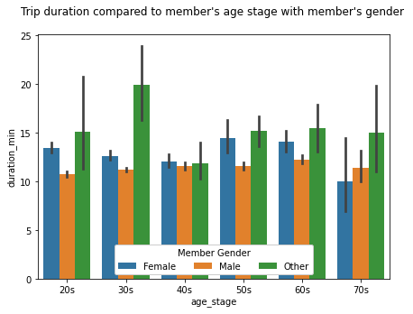

```python
# figure size
plt.figure(figsize = [7, 5])

# set clustered bar chart
ax = sb.barplot(data = df_clean, x = 'age_stage', y = 'duration_min', hue = 'member_gender')
ax.legend(loc = 8, ncol = 3, framealpha = 1, title = 'Member Gender');
plt.title("Trip duration compared to member's age stage with member's gender \n");
```

#### if we exclude genders other than male and female, we will noticed that females spend more trip duration than males in all age stages except males who's age stage in the 70s. And most of the trip duration between 10 minutes up to 15 minutes in all age stages.

[output not shown]

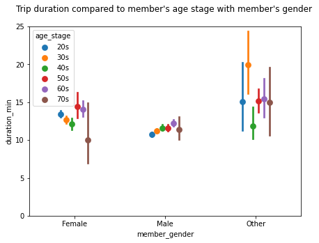

```python
# figure size
plt.figure(figsize = [7, 5])

# set point plot
ax = sb.pointplot(data = df_clean, x = 'member_gender', y = 'duration_min', hue = 'age_stage',
                   dodge = 0.3,linestyles = "")
plt.title("Trip duration compared to member's age stage with member's gender \n");
plt.ylim(0,25)
```

#### As we can see here, is that females in the 50s age stage are spending more trip duration than all other females in all other age stages and who's in the 70s are spending the lowest trip duration . And males in the 60s age stage are spending more trip duration than all other age stages, and who's in the 20s are spending the lowest trip duration.

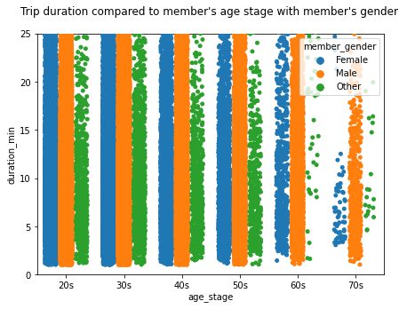

```python
# figure size
plt.figure(figsize = [7, 5])

# set stripplot
ax = sb.stripplot(data = df_clean, x = 'age_stage', y = 'duration_min', hue = 'member_gender',
                   dodge = True,jitter=0.3)
plt.title("Trip duration compared to member's age stage with member's gender \n")
plt.ylim(0,25);
```

#### As we can see here, that there is no big difference between all age stages, except males in the 70s, they spend more duration than females. (excluding other genders)

### Talk about some of the relationships you observed in this part of the investigation. Were there features that strengthened each other in terms of looking at your feature(s) of interest?

> I have observed the relation between member gender with age stage, and trip duration. and I have found that females spend more trip duration than males in all age stages, except males in 70s age stage spend more trip duration than females in 70s age stage.

### Were there any interesting or surprising interactions between features?

> With excluding other genders, i have been suprised by finding that males in the 60s age stage spend more trip duration than 20s,30s,40s,and 50s age stages, and females in the 50s age stage spend more trip duration than 20s,30s,and 40s.

```python
df_clean.to_csv("ford_gobike.csv",
           index=False)
```